# Projet

Abdoul DIALLO, Diaby DRAME

08/04/2022

**Table des matières**

# **1. Introduction**

# **2. Intervalles de confiance (non asymptotique)**

## **2.1. Définition**

## **2.2 Intervalle de confiance par l’inégalité de Bienaymé-Tchebychev**

## **2.2 Intervalle de confiance par l’inégalité de Hoeffding**

# **3. Intervalles de confiance asymptotique**

## **3.1. Définition**

## **3.2. Intervalle de confiance asymptotique du paramètre d’une loi de Bernoulli**

# **4. Performances des intervalles (Simulation)**

# **1. Introduction**

En statistique, les intervalles de confiance sont utilisés pour décrire le degré d’incertitude associé à une estimation d’échantillon d’un paramètre inconnu de la loi. La démarche consiste à construire à partir de l’échantillon un intervalle de confiance (le plus petit possible) dans lequel se trouve la valeur exacte du paramètre inconnu. Il existe deux types d’intervalles de confiance : les intervalles de confiance asymptotiques et les intervalles de confiance non asymptotique.

Notre étude portera sur l’illustration des performances des différents intervalles de confiance pour le paramètre inconnu $\theta$ de la loi de Bernoulli $B(\theta), {\theta \in ]0,1[}$

**Quelques définitions et théorèmes:**

Soient $(X_n)_{n\geq1}$ une suite de variables aléatoires et $X$ une variable aléatoire:

- $(X_n)_{n\geq1}$ converge en loi vers la variable aléatoire $X$, noté $X_n \underset{n \to +\infty}{\overset{\mathcal{L}}\longrightarrow}X$

si pour toute fonction continue et bornée $\phi$, on a
$$\mathbb{E}[\phi(X_{n})]\underset{n \to +\infty}{\longrightarrow}\mathbb{E}[\phi(X)]$$

- $(X_n)_{n\geq1}$ converge en loi vers la variable aléatoire $X$ si et seuleument si en tout point de continuité $x$ de $F_X$ (fonction de répartiton de $X$), on a
  $$F_{X_n}(x)\underset{n \to +\infty}{\longrightarrow}F_X(x)$$
- $(X_n)_{n\geq1}$ converge en probabilité vers la variable aléatoire $X$, noté $X_n \underset{n \to +\infty}{\overset{\mathbb{P}}\longrightarrow}X$, si
  $$\forall\epsilon > 0, \mathbb{P}(|X_n-X|\geq \epsilon)\underset{n \to +\infty}{\longrightarrow} 0$$
- $(X_n)_{n\geq1}$ converge presque surêment vers la variable aléatoire $X$, noté $X_n \underset{n \to +\infty}{\overset{p.s}\longrightarrow}X$, si
  $$\mathbb{P}(\lim_{n \to +\infty}X_n=X)=1$$
- La fonction $T(X_1,...,X_n) = T(\mathbb{X})$ est appellée statistique, si c’est une fonction mesurable de $(X_1,...,X_n)$
- $\mathbb{X} = (X_1,...,X_n)$ est i.i.d si les $X_i$ sont indépendantes et suivent une même loi.

**Théorème:** Loi des Grands Nombres

**Théorème:** Théorème Central Limite

Soit $(X_n)_{n\geq1}$ une suite de variables aléatoires i.i.d admettant un moment d’ordre 2 i.e $\mathbb{E}[X_{1}^{2}]<+\infty)$, d’espérance m et de variance $\sigma^2>0$.
Alors,
$$\sqrt{n}(\overline{X_{n}}-m)\underset{n \to +\infty}{\overset{\mathcal{L}}\longrightarrow}\mathcal{N}(0,\sigma^2)$$

# **2. Intervalles de confiance (non asymptotique)**

## **2.1. Définition**

Soient $(X_1,...,X_n)$ une suite variabes aléatoires i.i.d de paramètre inconnnu $\theta \in \Theta \subseteq \mathbb{R}^d$($d\geq1$) et $\alpha \in [0,1]$. On appelle intervalle de confiance non asymptotique de $\theta$ au niveau de confiance $1-\alpha$ tout invervalle aléatoire $(\underline\theta(\mathbb{X}),\overline\theta(\mathbb{X}))$ dont les deux bornes sont des statistiques et tel que pour tout $\theta\in\Theta$,
$$\mathbb{P}(\theta \in(\underline\theta(\mathbb{X}),\overline\theta(\mathbb{X})))\geq1-\alpha$$

## **2.2 Intervalle de confiance par l’inégalité de Bienaymé-Tchebychev**

**Propriété:** Bienaymé-Tchebychev

Soit $X$ une variable aléatoire, alors pour tout $\epsilon > 0$, on a
$$\mathbb{P}(|X-\mathbb{E}[X]| >\epsilon) \leq \frac{\mathbb{V}(X)}{\epsilon^2}$$

Dans notre étude $(X_1,...,X_n)$ est i.i.d de même loi de Bernoulli $B(\theta)$ avec $\theta$ inconnu.

On a $\mathbb{E}[X_1]=\theta$, donc par la loi des grands nombres, un estimateur naturel de $\theta$ est donné par la moyenne empirique $\overline{X_{n}}$.

Par ailleurs,
$$\mathbb{E}[\overline{X_{n}}]=\mathbb{E}[\frac{1}{n}\sum_{i=1}^{n}X_{i}]$$
Comme les $X_{i}$ sont de même loi et par linéarité de l’espérance, on a
$$\mathbb{E}[\overline{X_{n}}]=\frac{1}{n}\sum_{i=1}^{n}\mathbb{E}[X_{i}]=\frac{1}{n}\sum_{i=1}^{n}\mathbb{E}[X_{1}]=\mathbb{E}[X_{1}]=\theta$$

$$\mathbb{V}(\overline{X_{n}})=\mathbb{V}(\frac{1}{n}\sum_{i=1}^{n}X_{i}) = \frac{1}{n^2}\sum_{i=1}^{n}\mathbb{V}(X_{1}) = \frac{\theta(1-\theta)}{n}$$

En appliquant l’inégalité de Bienaymé-Tchebychev, on a
$$\mathbb{P}(|\overline{X_{n}}-\theta| > \epsilon) \leq \frac{\theta(1-\theta)}{n\epsilon^2}$$
Puis que $\theta(1-\theta) \leq 1/4$ pour tout $\theta \in ]0,1[$, on obtient
$$\mathbb{P}(|\overline{X_{n}}-\theta| > \epsilon) \leq \frac{1}{4n\epsilon^2}$$

Explicitons un intervalle de confiance de niveau $1-\alpha$ avec $\alpha \in [0,1]$ pour notre paramètre $\theta$:

On a $\forall \epsilon>0$,

$\mathbb{P}(|\overline{X_{n}}-\theta| > \epsilon) \leq \frac{1}{4n\epsilon^2} \Rightarrow$ $1 -\mathbb{P}(|\overline{X_{n}}-\theta| \leq \epsilon) \leq \frac{1}{4n\epsilon^2} \Rightarrow$ $\mathbb{P}(|\overline{X_{n}}-\theta| \leq \epsilon) \geq 1-\frac{1}{4n\epsilon^2}$

Posons $\alpha = \frac{1}{4n\epsilon^2}$ alors $\epsilon = \frac{1}{2\sqrt{n\alpha}}$, donc

$\mathbb{P}(-\frac{1}{2\sqrt{n\alpha}}\leq\overline{X_{n}}-\theta \leq \frac{1}{2\sqrt{n\alpha}}) \geq 1-\alpha \indent \Rightarrow$ $\mathbb{P}(\overline{X_{n}}-\frac{1}{2\sqrt{n\alpha}}\leq\theta \leq \overline{X_{n}}+\frac{1}{2\sqrt{n\alpha}}) \geq 1-\alpha$

Ainsi un intervalle de confiance (non asymptotique) de niveau $1-\alpha$ pour $\theta$ est donné par
$$\left[\overline{X_{n}}-\frac{1}{2\sqrt{n\alpha}},\overline{X_{n}}+\frac{1}{2\sqrt{n\alpha}}\right]$$

```r
IC_bc <- function(obs,alpha){
n <- length(obs)
m <- mean(obs)
i <- m - 1/(2*sqrt(n*alpha))
s <- m + 1/(2*sqrt(n*alpha))
return (list(inf_bc = i, sup_bc=s))
}

real <- function(size,theta){
  u <- runif(size)
  B <- u < theta
  return (B)
}

obs <- real(1000,0.4)
IC_bc(obs,0.05)
```

```
## $inf_bc
## [1] 0.3612893
##
## $sup_bc
## [1] 0.5027107
```

## **2.2 Intervalle de confiance par l’inégalité de Hoeffding**

**Propriété:** Hoeffding

Soit $X_1,...,X_n$ des variables aléatoires indépendantes et bornées, avec $a_i \leq X_i \leq b_i$. Alors $\epsilon>0$,
$$\mathbb{P}(|S_n-\mathbb{E}[S_n]| > \epsilon) \leq 2\exp{(-\frac{2\epsilon^2}{\sum_{i=1}^{n}(b_i-a_i)^2})}$$
avec $S_n = \sum_{i=1}^{n}X_i$

En se ramenant à notre étude de la suite $(X_1,...,X_n)$ i.i.d de même loi de Bernoulli $B(\theta)$ avec $\theta$ inconnu, on peut expliciter un intervalle de confiance pour $\theta$ comme précédemment à l’aide de cette fois-ci de l’inégalité de Hoeffding:

Les $X_i$ étant de même loi, on peut prendre $a_i=a$ et $b_i=b$ $\forall i \in {1,...,n}$. On aura
$$\mathbb{P}(|S_n-\mathbb{E}[S_n]| > \epsilon) \leq 2\exp{(-\frac{2\epsilon^2}{n(b-a)^2})}$$

$\epsilon$ étant quelconque, prenons $\epsilon = \epsilon n$, donc

$\mathbb{P}(|\frac{S_n}{n}-\mathbb{E}[\frac{S_n}{n}]| > \epsilon) \leq 2\exp{(-\frac{2\epsilon^2n^2}{n(b-a)^2})} \Longleftrightarrow$ $\mathbb{P}(|\overline{X_{n}}-\mathbb{E}[\overline{X_{n}}]| > \epsilon) \leq 2\exp{(-\frac{2\epsilon^2n}{(b-a)^2})}$

Comme nos $X_i$ sont de Bernoulli, alors $a=0$ et $b=1$, d’où
$$\mathbb{P}(|\overline{X_{n}}-\theta| > \epsilon) \leq 2\exp{(-2\epsilon^2n)}$$

En posant $\alpha = 2exp(-2\epsilon^2n)$ et suivant la même démarche (celle dans l’inégalité de Bienaymé-Tchebychev), nous obtenons un intervalle de confiance (non asymptotique) de niveau $1-\alpha$ donné par
$$\left[\overline{X_{n}}-\sqrt{\frac{-\log{\alpha/2}}{2n}},\overline{X_{n}}+\sqrt{\frac{-\log{\alpha/2}}{2n}}\right]$$

```r
IC_hoef <- function(obs,alpha){
n <- length(obs)
m <- mean(obs)
i <- m - sqrt(-log(alpha/2)/(2*n))
s <- m + sqrt(-log(alpha/2)/(2*n))
return (list(inf_H = i, sup_H=s))
}

real <- function(size,theta){
  u <- runif(size)
  B <- u < theta
  return (B)
}

obs <- real(1000,0.4)
IC_hoef(obs,0.05)
```

```
## $inf_H
## [1] 0.3570531
##
## $sup_H
## [1] 0.4429469
```

# **3. Intervalles de confiance asymptotique**

## **3.1. Définition**

Soient $(X_1,...,X_n)$ une suite variabes aléatoires i.i.d de paramètre inconnnu $\theta \in \Theta \subseteq \mathbb{R}^d$($d\geq1$) et $\alpha \in [0,1]$. On appelle intervalle de confiance asymptotique de $\theta$ au niveau de confiance $1-\alpha$ tout invervalle aléatoire $(\underline\theta(\mathbb{X}),\overline\theta(\mathbb{X}))$ dont les deux bornes sont des statistiques et tel que pour tout $\theta\in\Theta$,
$$\lim_{n\to +\infty} \mathbb{P}(\theta \in(\underline\theta(X),\overline\theta(X)))\geq1-\alpha$$

## **3.2. Intervalle de confiance asymptotique du paramètre d’une loi de Bernoulli**

Considérons une suite de variables aléatoires $(X_1,...,Xn)$ i.i.d de Bernoulli de paramètre $\theta$ inconnu.  
On explique ici comment obtenir à l’aide du Théorème Central Limite (TCL) un intervalle de confiance pour $\theta$.

Dans notre cas, on a:
$$\mathbb{E}[X_1] = \theta, \mathbb{V}(X_1) = \theta(1-\theta)$$
Par le TCL
$$\sqrt{n}(\overline{X_{n}}-\theta)\underset{n \to +\infty}{\overset{\mathcal{L}}\longrightarrow}\mathcal{N}(0,\theta(1-\theta))$$
donc
$$\frac{\sqrt{n}}{\sqrt{\theta(1-\theta}}(\overline{X_{n}}-\theta)\underset{n \to +\infty}{\overset{\mathcal{L}}\longrightarrow}\mathcal{N}(0,1)$$

Par définition de la convergence en loi (celle avec les fonctions de répartition), on obtient pour tous a<b réels:
$$\lim_{n\to +\infty} \mathbb{P}(a<\sqrt{n}(\frac{\overline{X_{n}}-\theta}{\sqrt{\theta(1-\theta)}})\leq{b})=\mathbb{P}(a<Z\leq{b})=\Phi(b)-\Phi(a)$$
Avec $Z \sim \mathcal{N}(0,1)$ et $\Phi$ la fonction de répartition de $Z$.

On souhaite obtenir un intervalle de confiance asymptotique de niveau de confiance $1-\alpha$.

Pour cela, on doit avoir: $\Phi(b)-\Phi(a)\geq1-\alpha$.

Il y’a une infinité de façons de choisir a et b. Le choix récurrent est a=-b (intervalle centré en la moyenne empirique). Dans ce cas, on a:

$$\Phi(b)-\Phi(a)=\Phi(b)-\Phi(-b)$$

Par symétrie de $Z$ par rapport à 0, on a $\Phi(-b) = 1-\Phi(b$), donc
$$\Phi(b)-\Phi(a)=\Phi(b)-\Phi(-b)=\Phi(b)-(1-\Phi(b))=2\Phi(b)-1$$

On cherche alors b tels que: $2\Phi(b)-1=1-\alpha$ $\Leftrightarrow$ $\Phi(b)=1-\frac{\alpha}{2}$

$\Phi$ étant continue et strictement croissante sur $\mathbb{R}$, elle réalise une bijection de $\mathbb{R}$ dans $\Phi(\mathbb{R})=]0,1[$. Il éxiste donc un unique réel $t_{\alpha}$ tel que $\Phi(t_{\alpha})=1-\frac{\alpha}{2}$. On pose par la suite $b=t_{\alpha}$ et $a =- t_{\alpha}$.  
Ainsi on obtient que $b=t_{\alpha}= q_{1-\frac{\alpha}{2}}$ et $a=-t_{\alpha}=-q_{1-\frac{\alpha}{2}}$ avec $q_{1-\frac{\alpha}{2}}=\Phi^{-1}(1-\frac{\alpha}{2})$ le quantile d’ordre $1-\frac{\alpha}{2}$ de $Z$.

Comme la loi normale centré reduite est symétrique on a $-q_{1-\frac{\alpha}{2}}=q_{\frac{\alpha}{2}}$

Donc ainsi nous avons
$$\lim_{n\to +\infty} \mathbb{P}(a<\sqrt{n}(\frac{\overline{X_{n}}-\theta}{\sqrt{\theta(1-\theta)}})\leq{b})=\lim_{n\to +\infty} \mathbb{P}(-q_{1-\frac{\alpha}{2}}<\sqrt{n}(\frac{\overline{X_{n}}-\theta}{\sqrt{\theta(1-\theta)}})\leq{q_{1-\frac{\alpha}{2}}})=\lim_{n\to +\infty} \mathbb{P}\left(\lvert\overline{X_{n}}-\theta\rvert\leq\frac{\sqrt{\theta(1-\theta)}}{\sqrt{n}}q_{1-\frac{\alpha}{2}}\right)=1-\alpha$$
Comme on sait que $\theta$ le paramétre de Bernoulli est dans ]0,1[ donc on: $\theta(1-\theta)\leq\frac{1}{4}$ alors,
$$\lim_{n\to +\infty} \mathbb{P}\left(\lvert\overline{X_{n}}-\theta\rvert\leq\frac{{1}}{2\sqrt{n}}q_{1-\frac{\alpha}{2}}\right)\geq1-\alpha$$
Un intervalle de confiance asymptotique pour $\theta$ de niveau de confiance $1-\alpha$ est :
$$\left[\overline{X_{n}}-\frac{{1}}{2\sqrt{n}}q_{1-\frac{\alpha}{2}},\overline{X_{n}}+\frac{{1}}{2\sqrt{n}}q_{1-\frac{\alpha}{2}}\right]$$

```r
IC_Asym <- function(obs,alpha){
n <- length(obs)
m <- mean(obs)
q <- qnorm(1- alpha/2)
i <- m - q/(2*sqrt(n))
s <- m + q/(2*sqrt(n))
return (list(inf_A = i, sup_A=s))
}

real <- function(size,theta){
  u <- runif(size)
  B <- u < theta
  return (B)
}

obs <- real(1000,0.4)
IC_Asym(obs,0.05)
```

```
## $inf_A
## [1] 0.3770102
##
## $sup_A
## [1] 0.4389898
```

# **4. Performances des intervalles (Simulation)**

```r
simul <- function(size,theta,M,alpha){
  P_bc <- 0
  P_H <- 0
  P_A <- 0

  for(i in 1:M){
    obs <- real(size,theta)
    IC_bc <- IC_bc(obs,alpha)
    if(IC_bc$inf_bc <= theta && theta <= IC_bc$sup_bc ) { P_bc <- P_bc + 1}

    IC_hoef <- IC_hoef(obs,alpha)
    if(IC_hoef$inf_H <= theta && theta <= IC_hoef$sup_H ) { P_H <- P_H + 1}

    IC_as <- IC_Asym(obs,alpha)
    if(IC_as$inf_A <= theta && theta <= IC_as$sup_A ) { P_A <- P_A + 1}

  }

  return (list(prop_BC = P_bc/M, prop_Hoef=P_H/M, prop_Asym = P_A/M))
}
```

```r
simul(5,0.36,200,0.05)
```

```
## $prop_BC
## [1] 1
##
## $prop_Hoef
## [1] 0.995
##
## $prop_Asym
## [1] 0.95
```

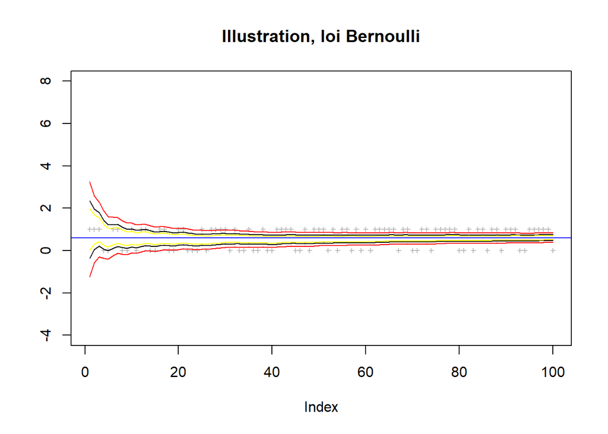

```r
x = real(100,0.6)
I = NULL
S = NULL
i = NULL
c = NULL

m = NULL
n = NULL

for(k in 1:length(x)){
  a = IC_bc(x[1:k],0.05)
  b = IC_hoef(x[1:k],0.05)
  f = IC_Asym(x[1:k],0.05)
  I[k] = a$inf_bc
  S[k] = a$sup_bc
  i[k] = b$inf_H
  c[k] = b$sup_H
  m[k] = f$inf_A
  n[k] = f$sup_A
}

plot(x, ylim = c(-4,8), ylab = NA, pch = 3, cex=.5,
col="grey", main = "Illustration, loi Bernoulli")
lines(I,col="red")
lines(S,col="red")
lines(i,col="black")
lines(c,col="black")
lines(m,col="yellow")
lines(n,col="yellow")
abline(h=0.6,col="blue")
```